[figure not shown]

# CEOS-ARD - Synthetic Aperture Radar - Polarimetric Radar

## Document Status

Product Family Specification, Synthetic Aperture Radar, Polarimetric Radar

Proposed revisions may be provided to: ard-contact@lists.ceos.org

## Document History

Not available yet

## Contributing Authors

- François Charbonneau, Natural Resources Canada, Canada
- Ake Rosenqvist, soloEO / Japan Aerospace Exploration Agency (JAXA), Japan
- John Truckenbrodt, German Aerospace Centre (DLR), Germany
- Clément Albinet, European Space Agency (ESA), Italy
- David Small, University of Zurich, Switzerland
- Bruce Chapman, Jet Propulsion Laboratory, USA
- Howard Zebker, Stanford University, USA
- Zheng-Shu Zhou, CSIRO, Australia
- Virginia Brancato, Jet Propulsion Laboratory, USA
- Danilo Dadamia, CONAE, Argentina
- Benjamin Deschamps, Environment and Climate Change, Canada
- Guillaume Hajduch, Collecte Localisation Satellites, France
- Josef Kellndorfer, Earth Big Data, USA
- Marco Lavalle, Jet Propulsion Laboratory, USA
- Adam Lewis, Geoscience Australia, Australia
- Thomas Logan, Alaska Satellite Facility, USA
- Franz Meyer, Alaska Satellite Facility, USA
- Nuno Miranda, European Space Agency (ESA), Italy
- Muriel Pinheiro, European Space Agency (ESA), Italy
- Marko Repse, Sinergise, Slovenia
- HariPriya Sakethapuram, ISRO, India
- Andreia Siqueira, Geoscience Australia, Australia
- Gustavo Shiroma, Jet Propulsion Laboratory, USA
- Takeo Tadono, Japan Aerospace Exploration Agency, Japan
- Medhavy Thankappan, Geoscience Australia, Australia
- Antonio Valentino, RHEA for European Space Agency (ESA), Italy
- Anna Wendleder, German Aerospace Centre (DLR), Germany
- Fang Yuan, Digital Earth Africa, Australia

## CEOS Analysis Ready Data Definition

> CEOS Analysis Ready Data (CEOS-ARD) are satellite data that have been processed to a minimum set of requirements and organized into a form that allows immediate analysis with a minimum of additional user effort and interoperability both through time and with other datasets.

## Description

**Product Family Specification:** Synthetic Aperture Radar, Polarimetric Radar (SAR-POL)

**Version:** 1.2-draft

**Applies to:** Data collected by Synthetic Aperture Radar sensors

## Background

This PFS is specifically aimed at users interested in exploring the potential of SAR but who may lack the expertise or facilities for SAR processing.

The CEOS-ARD Polarimetric Radar (POL) product format is an extension of the CEOS-ARD Normalised Radar Backscatter (NRB) format. This extension is required in order to better support Level-1 SLC polarimetric data, including full-polarimetric modes (e.g., RADARSAT-2, ALOS-2/4, SAOCOM-1 and future missions), and hybrid or linear dual-polarimetric modes (i.e., Compact Polarimetric mode available on RCM, SAOCOM and the upcoming NISAR mission).The POL product can be defined in two processing levels:

The **normalised covariance matrix (CovMat)** representation (C2 or C3) which preserves the inter-channel polarimetric phase(s) and maximizes the available information for users. Interoperability within current CEOS-ARD SAR backscatter definition is preserved, since diagonal elements of the covariance matrix are backscatter intensities. Scattering information enhancement can be achieved by applying incoherent polarimetric decomposition techniques (e.g., Freeman-Durden, van Zyl, Cloude-Pottier, Yamaguchi-based) directly on the C2 or C3 matrix.

**Polarimetric Radar Decomposition (PRD)** refers to ARD products where polarimetric information is broken down into simplified parameters to facilitate user interpretation of the data. They are derived from coherent or incoherent polarimetric decomposition techniques.

### Notice and Limitations

For Polarimetric Radar (POL) products, optimal incoherent Polarimetric Radar Decomposition (PRD) should be performed under the slant range projection (Gens, Atwood, and Pottier 2013; Toutin et al. 2013). In order to minimise bias in the CEOS-ARD SAR Level-2A covariance matrix product, speckle filtering and averaging of the covariance matrix should be applied in the slant range projection, and geocoding should be performed using nearest-neighbour resampling. Specifically, nearest-neighbour resampling ensures that the averaged covariance matrix elements in slant range and in geocoded ground projection are exactly the same. Consequently, the polarimetrically derived parameters are exactly equal in both approaches (assuming that no further averaging is performed on the ARD product for decomposing the polarimetric information). Bilinear and average resampling methods are also suitable for resampling the covariance matrix, but some differences with polarimetric parameters generated in slant range and then resampled (bilinear) might be observed on sloped terrains. Even if Sinc interpolation may be more robust for spatial resampling, it does not preserve covariance matrix integrity, and should consequently not be used for this ARD product.

It is recommended that ARD providers who desire to distribute PRD products decompose the polarimetric information starting from Level-1 SLC data and then geocode the derived parameters rather than use the CovMat ARD product. Resampling can be performed using any of the supported methods (nearest-neighbour, bilinear, average, bi-cubic spline or Lanczos are recommended), which need to be indicated in the product metadata. Note that coherent decomposition techniques cannot be performed on CovMat ARD products.

Covariance matrix products contain a variable number of layers (or bands) with different data types depending on the polarimetric mode (full or dual) and decomposition technique. The CovMat products for the C2 matrix have 3 layers (2 real-valued diagonal elements and 1 complex-valued off-diagonal element). CovMat products for the C3 matrix have 6 layers (3 real-valued diagonal elements and 3 complex-valued off-diagonal elements). Layers that can be obtained via a complex conjugation of other layers are not provided within the product. Polarimetric Decomposition products contain typically 2 to 4 (or more) real-valued layers depending on the particular decomposition algorithm. Within the CovMat product files, ARD layers are organized in order to reduce access delays and maximize efficiency in extracting the desired information. In CovMat products, geographically contiguous samples for each layer may be stored next to each other and organized “layer by layer”. Alternatively, samples belonging to the same covariance matrix might be stored next to each other and organized “matrix by matrix”. PRD products are organized “layer by layer”, i.e., with bands corresponding to the output of the polarimetric decomposition stored next to each other.

## Definitions and Abbreviations

**ALE**

Absolute Geolocation Error

**ATBD**

Algorithm Theoretical Basis Document

**Auxiliary Data**

The data required for instrument processing, which does not originate in the instrument itself or from the satellite. Some auxiliary data will be generated in the ground segment, whilst other data will be provided from external sources, e.g., DEM, aerosols.

**CEOS-ARD**

Committee on Earth Observation Satellites - Analysis Ready Data

**CovMat**

Normalised Radar Covariance Matrix

**CRS**

Coordinate Reference System

**DEM**

Digital Elevation Model

**DOI**

Digital Object Identifier

**DSM**

Digital Surface Model

**EGM**

Earth Gravitational Model

**ENL**

Equivalent Number of Looks

**EPSG Code**

An EPSG code is a unique identifier assigned to e.g. a specific coordinate reference system (CRS) by the European Petroleum Survey Group (EPSG).

**GSLC**

Geocoded Single-Look Complex

**ISLR**

Intensity Signal-to-Noise Level Ratio

**LUT**

Look-Up Table

**Metadata**

Structured information that describes other information or information services. With well-defined metadata, users should be able to get basic information about data, without the need to have knowledge about its entire content.

**NRB**

Normalised Radar Backscatter

**ORB**

Ocean Radar Backscatter

**POL**

Polarimetric Radar

**PRD**

Polarimetric Radar Decomposition

**PSLR**

Polarimetric Signal-to-Noise Level Ratio

**rRMSE**

Radial Root Mean Square Error

**RTC**

Radiometrically Terrain Corrected

**SAR**

Synthetic Aperture Radar

**SI**

International System of Units, internationally known by the abbreviation SI (from French Système international d’unités)

**SLC**

Single-Look Complex

**STAC**

SpatioTemporal Asset Catalog

**UPS**

Universal Polar Stereographic

**URL**

Uniform Resource Locator, a reference to a web resource that specifies its location on a computer network and a mechanism for retrieving it.

**UTC**

Coordinated Universal Time

**UTM**

Universal Transverse Mercator

**WGS84**

World Geodetic System 1984

**WKT**

Well-Known Text (WKT) is a text markup language for representing vector geometry objects on a map, spatial reference systems of spatial objects, and transformations between spatial reference systems. The formats were originally defined by the Open Geospatial Consortium (OGC) and described in their Simple Feature Access and Coordinate Transformation Service specifications.

## Requirements

**WARNING:** The section numbers in front of the title (e.g. 1.1) are not stable and may change or may be removed at any time. Do **not** use the numbers to refer back to specific requirements! Instead, use the textual identifier that is provided below the title.

### `1.` General Metadata

These are metadata records describing a distributed collection of pixels. The collection of pixels referred to must be contiguous in space and time. General metadata should allow the user to assess the *overall* suitability of the dataset, and must meet the requirements listed below.

#### `1.1.` Traceability

Identifier: `meta.metadata-traceability-sar`

##### Threshold requirements:

Not required.

##### Goal requirements:

Data must be traceable to SI reference standard.

Notes:

1. Relationship to Section “Radiometrically Corrected Measurements: Radiometric Accuracy”. Traceability requires an estimate of measurement uncertainty.
2. Information on traceability should be available in the metadata as a single DOI landing page.

#### `1.2.` Metadata Machine Readability

Identifier: `meta.metadata-machine-readability-sar`

##### Threshold requirements:

Metadata is provided in a structure that enables a computer algorithm to be used to consistently and automatically identify and extract each component/variable/layer for further use.

##### Goal requirements:

As threshold, but metadata is formatted in accordance with CEOS-ARD SAR Metadata Specifications, v.1.1, or in a community endorsed standard that facilitates machine-readability, such as ISO 19115-2, Climate and Forecast (CF) convention, the Attribute Convention for Data Discovery (ACDD), etc.

#### `1.3.` Product Type

Identifier: `meta.metadata-product-type-sar`

##### Threshold requirements:

CEOS-ARD product type name – or names in case of compliance with more than one product type – and, if required by the data provider, copyright.

##### Goal requirements:

As threshold.

#### `1.4.` Document Identifier

Identifier: `meta.metadata-pfs-url`

##### Threshold requirements:

Reference to CEOS-ARD PFS document as URL.

##### Goal requirements:

As threshold.

#### `1.5.` Data Collection Time

Identifier: `meta.metadata-time-sar`

##### Threshold requirements:

Number of source data acquisitions of the data collection is identified. The start and stop UTC time of data collection is identified in the metadata, expressed in date/time. In case of composite products, the dates/times of the first and last data takes and the per-pixel metadata Section “Per-Pixel Metadata: Acquisition ID Image” is provided with the product.

##### Goal requirements:

As threshold.

### `2.` Source Metadata

These are metadata records describing (detailing) **each** acquisition (source data) used to generate the ARD product. This may be one or mutliple acquisitions.

#### `2.1.` Acquisition ID

Identifier: `src.metadata-acquisition-id`

##### Threshold requirements:

Each acquisition is identified through a sequential identifier in the metadata, e.g. acqID = 1, 2, 3.

##### Goal requirements:

As threshold.

#### `2.2.` Source Data Access

Identifier: `src.metadata-data-access-source`

##### Threshold requirements:

The metadata identifies the location from where the source data can be retrieved, expressed as a URL or DOI.

##### Goal requirements:

The metadata identifies an online location from where the data can be consistently and reliably retrieved by a computer algorithm without any manual intervention being required.

#### `2.3.` Instrument

Identifier: `src.metadata-instrument-sar`

##### Threshold requirements:

The instrument used to collect the data is identified in the metadata:

- Satellite name
- Instrument name

##### Goal requirements:

As threshold, but including a reference to the relevant [CEOS Missions, Instruments and Measurements Database](https://ceos.org/mim-database/) record.

#### `2.4.` Source Data Acquisition Time

Identifier: `src.metadata-time-source`

##### Threshold requirements:

The start date and time of source data is identified in the metadata, expressed in UTC in date and time, at least to the second.

##### Goal requirements:

As threshold.

#### `2.5.` Source Data Acquisition Parameters

Identifier: `src.metadata-acquisition-parameters-sar`

##### Threshold requirements:

Acquisition parameters related to the SAR antenna:

- Radar band
- Centre frequency
- Observation mode (i.e., beam mode name)
- Polarization(s) (listed as in original product)
- Antenna pointing (right/left)
- Beam ID (i.e., beam mode mnemonic)

##### Goal requirements:

As threshold.

#### `2.6.` Source Data Orbit Information

Identifier: `src.metadata-orbit`

##### Threshold requirements:

Information related to the platform orbit used for data processing:

- Pass direction (asc/desc)[^1]
- Orbit data source (e.g., predicted, definite, precise, downlinked, etc.)

##### Goal requirements:

As threshold, including also:

- Platform heading angle expressed in degrees (0-360) from North
- Orbit data file containing state vectors (minimum of 5 state vectors, from 10% of scene length before start time to 10% of scene length after stop time)
- Platform (mean) altitude

#### `2.7.` Source Data Processing Parameters

Identifier: `src.metadata-processing-parameters`

##### Threshold requirements:

Processing parameters details of the source data:

- Processing facility
- Processing date
- Software version
- Product level
- Product ID (file name)
- Azimuth number of looks
- Range number of looks (separate values for each beam, as necessary)

##### Goal requirements:

As threshold, plus additional relevant processing parameters, e.g., range- and azimuth look bandwidth and LUT applied.

#### `2.8.` Source Data Image Attributes

Identifier: `src.metadata-image-attributes-sar`

##### Threshold requirements:

Image attributes related to the source data:

- Source Data geometry (slant range/ground range)
- Azimuth pixel spacing [m] (alternatively, Azimuth pixel spacing can be provided in second [s], equivalent to the azimuth time sample interval)
- Range pixel spacing
- Azimuth resolution
- Range resolution
- Near range incident angle
- Far range incident angle

##### Goal requirements:

Geometry of the image footprint expressed in WGS84 in a standardised format (e.g., WKT).

#### `2.9.` Sensor Calibration

Identifier: `src.metadata-sensor-calibration-sar`

##### Threshold requirements:

Not required.

##### Goal requirements:

Sensor calibration parameters are identified in the metadata or can be accessed using details included in the metadata. Ideally this would support machine-to-machine access.

#### `2.10.` Performance Indicators

Identifier: `src.metadata-performance-indicators`

##### Threshold requirements:

Provide performance indicators on data intensity noise level ($\text{NE}\sigma^0$ and/or $\text{NE}\beta^0$ and/or $\text{NE}\gamma^0$, i.e., noise equivalent Sigma- and/or Beta- and/or Gamma-Nought). Provided for each polarization channel when available.

Parameter may be expressed as the mean and/or minimum and maximum noise equivalent values of the source data.

Values do not need to be estimated individually for each product, but may be estimated once for each acquisition mode, and annotated on all products.

##### Goal requirements:

Provide additional relevant performance indicators (e.g., ENL, PSLR, ISLR, and performance reference DOI or URL).

#### `2.11.` Polarimetric Calibration Matrices

Identifier: `src.metadata-polarimetric-calibration-matrices`

##### Threshold requirements:

Not required.

##### Goal requirements:

The complex-valued polarimetric distortion matrices with the channel imbalance and the cross-talk applied for the polarimetric calibration.

#### `2.12.` Mean Faraday Rotation Angle

Identifier: `src.metadata-mean-faraday-rotation-angle`

##### Threshold requirements:

Not required.

##### Goal requirements:

The mean Faraday rotation angle estimated from the polarimetric data and/or from models with reference to the method or paper used to derive the estimate.

#### `2.13.` Ionosphere Indicator

Identifier: `src.metadata-ionosphere-indicator`

##### Threshold requirements:

Not required.

##### Goal requirements:

Flag indicating whether the backscatter imagery is “significantly impacted” by the ionosphere (0 – false, 1 – true). Significant impact would imply that the ionospheric impact on the backscatter exceeds the radiometric calibration requirement or goal for the imagery.

### `3.` Product Metadata

Information related to the CEOS-ARD product generation procedure and geographic parameters.

#### `3.1.` Product Data Access

Identifier: `prd.metadata-data-access-product`

##### Threshold requirements:

Processing parameters details of the CEOS-ARD product:

- Processing facility
- Processing date
- Software version
- Location from where CEOS-ARD product can be retrieved, expressed as a URL or DOI.

##### Goal requirements:

The metadata identifies an online location from where the data can be consistently and reliably retrieved by a computer algorithm without any manual intervention being required.

#### `3.2.` Auxiliary Data

Identifier: `prd.metadata-auxiliary-data`

##### Threshold requirements:

Not required.

##### Goal requirements:

The metadata identifies the sources of auxiliary data used in the generation process, ideally expressed as DOIs.

Notes:

1. Auxiliary data includes DEMs, etc., and any additional data sources used in the generation of the product.

#### `3.3.` Product Sample Spacing

Identifier: `prd.metadata-sample-spacing`

##### Threshold requirements:

CEOS-ARD product processing parameters details:

- Pixel (column) spacing
- Line (row) spacing

##### Goal requirements:

As threshold.

#### `3.4.` Product Equivalent Number of Looks

Identifier: `prd.metadata-enl`

##### Threshold requirements:

Not required.

##### Goal requirements:

Equivalent Number of Looks (ENL)

#### `3.5.` Product Resolution

Identifier: `prd.metadata-resolution`

##### Threshold requirements:

Not required.

##### Goal requirements:

Average spatial resolution of the CEOS-ARD product along:

- Columns
- Rows

#### `3.6.` Product Filtering

Identifier: `prd.metadata-speckle-filtering-pol`

##### Threshold requirements:

Flag if speckle filter has been applied (True/False).

Metadata should include:

- Reference to algorithm as DOI or URL
- Input filtering parameters
  - Type
  - Window size in pixel units
  - Any other parameters defining the speckle filter used

Advanced polarimetric filter preserving covariance matrix properties should be applied.

##### Goal requirements:

As threshold.

#### `3.7.` Product Bounding Box

Identifier: `prd.metadata-geo-bbox`

##### Threshold requirements:

Two opposite corners of the product file (bounding box, including any zero-fill values) are identified, expressed in the coordinate reference system defined in Section “Product Metadata: Product Coordinate Reference System”.

Notes:

1. Four corners of the product file are recommended for scenes crossing the Antemeridian, or the North or the South Pole.

##### Goal requirements:

As threshold.

#### `3.8.` Product Geographical Extent

Identifier: `prd.metadata-geo-area`

##### Threshold requirements:

The geometry of the SAR image footprint expressed in WGS84, in a standardised format (e.g., WKT Polygon).

##### Goal requirements:

As threshold.

#### `3.9.` Product Image Size

Identifier: `prd.metadata-image-size`

##### Threshold requirements:

Image attributes of the CEOS-ARD product:

- Number of lines
- Number of pixels per line
- File header size (if applicable)
- Number of no-data border pixels (if applicable)

##### Goal requirements:

As threshold.

#### `3.10.` Product Pixel Coordinate Convention

Identifier: `prd.metadata-pixel-coordinate-convention`

##### Threshold requirements:

Coordinate referring to the centre, the upper left corner, or the lower left corner of a pixel. Values are [pixel centre, pixel ULC or pixel LLC].

##### Goal requirements:

As threshold.

#### `3.11.` Product Coordinate Reference System

Identifier: `prd.metadata-crs`

##### Threshold requirements:

The metadata lists the map projection (or geographical coordinates, if applicable) that was used and any relevant parameters required to geolocate data in that map projection, expressed in a standardised format (e.g., WKT).  
Indicate EPSG code, if defined for the CRS.

##### Goal requirements:

As threshold.

#### `3.12.` Reference Orbit

Identifier: `prd.metadata-orbit-reference-nrb-pol`

**Usage: Only when Flattened phase per-pixel metadata (see Section “Radiometrically Corrected Measurements: Flattened Phase”) is provided.**

##### Threshold requirements:

Not required.

##### Goal requirements:

Provide the absolute orbit number used as reference for topographic phase flattening. In case a virtual orbit has been used, provide orbit parameters or orbit state vectors as DOI or URL.

Provide scene-centred perpendicular baseline for the for the source data relative to the reference orbit used (for approximate use only).

### `4.` Per-Pixel Metadata

The following minimum metadata specifications apply to each pixel. Whether the metadata are provided in a single record relevant to all pixels or separately for each pixel is at the discretion of the data provider. Per-pixel metadata should allow users to discriminate between (choose) observations on the basis of their individual suitability for applications.

#### `4.1.` Cloud Optimized Formats

Identifier: `pxl.cloud-optimized-formats`

##### Threshold requirements:

Not required.

##### Goal requirements:

All files are provided using cloud-optimized file formats.

#### `4.2.` Metadata Machine Readability

Identifier: `pxl.metadata-machine-readability-sar`

##### Threshold requirements:

Metadata is provided in a structure that enables a computer algorithm to be used to consistently and automatically identify and extract each component/variable/layer for further use.

##### Goal requirements:

As threshold, but metadata is formatted in accordance with CEOS-ARD SAR Metadata Specifications, v.1.1, or in a community endorsed standard that facilitates machine-readability, such as ISO 19115-2, Climate and Forecast (CF) convention, the Attribute Convention for Data Discovery (ACDD), etc.

#### `4.3.` Data Mask Image

Identifier: `pxl.per-pixel-data-mask`

##### Threshold requirements:

Mask image indicating:

- Valid data
- Invalid data
- No data

File format specifications/contents provided in metadata:

- Sample Type (Mask)
- Data Format (GeoTIFF, HDF5, NetCDF, …)
- Data Type (Int, …)
- Bits per Sample
- Byte Order
- Bit Value Representation

##### Goal requirements:

As threshold, including additional bit value representations, e.g.:

- Layover (masked as invalid data in threshold)
- Radar shadow (masked as invalid data in threshold)
- Ocean water
- Land (recommended for ORB)
- RTC applied (e.g., for maritime scenes with land samples for which RTC has been applied)
- DEM gap filling (i.e., interpolated DEM over gaps)

#### `4.4.` Scattering Area Image

Identifier: `pxl.per-pixel-scattering-area`

**Usage: Recommended for scenes that include land areas.**

##### Threshold requirements:

Not required.

##### Goal requirements:

DEM-based scattering area image used for Gamma-Nought terrain normalisation is provided. This quantifies the local scattering area used to normalise for radiometric distortions induced by terrain to the measured $\beta^0$ backscatter. The terrain-flattened $\gamma^0_T$ is best understood as $\beta^0$ divided by the local scattering area.

File format specifications/contents provided in metadata:

- Sample Type (Scattering Area)
- Data Format (GeoTIFF, HDF5, NetCDF, …)
- Data Type (Int, Float, …)
- Bits per Sample
- Byte Order

#### `4.5.` Local Incident Angle Image

Identifier: `pxl.per-pixel-local-incident-angle`

##### Threshold requirements:

DEM-based Local Incident angle image is provided.

File format specifications/contents provided in metadata:

- Sample Type (Angle)
- Data Format (GeoTIFF, HDF5, NetCDF, …)
- Data Type (Int, Float, …)
- Bits per Sample
- Byte Order

Notes:

1. For maritime ORB scenes when no land areas are covered, a geoid model could be used for the calculation of the local incident angle.

##### Goal requirements:

As threshold.

#### `4.6.` Ellipsoidal Incident Angle Image

Identifier: `pxl.per-pixel-ellipsoidal-incident-angle`

##### Threshold requirements:

Not required.

##### Goal requirements:

Ellipsoidal incident angle is provided.

File format specifications/contents provided in metadata:

- Sample Type (Angle)
- Data Format (GeoTIFF, HDF5, NetCDF, …)
- Data Type (Int, Float, …)
- Bits per Sample
- Byte Order
- Reference Ellipsoid Name

Notes:

1. For maritime ORB scenes when no land areas are covered, the ellipsoidal incident angle is nearly identical to the geoid based local incident angle.

#### `4.7.` Noise Power Image

Identifier: `pxl.per-pixel-noise-power`

##### Threshold requirements:

Not required.

##### Goal requirements:

Estimated Noise Equivalent $\sigma^0$ (or $\beta^0$ or $\gamma^0$, as applicable) used for noise removal, if applied, for each channel. $\text{NE}\sigma^0$ and $\text{NE}\gamma^0$ are both based on a simplified ellipsoid Earth model.

File format specifications/contents provided in metadata:

- Sample Type (Gamma-Nought, Sigma-Nought, Beta-Nought)
- Data Format (GeoTIFF, HDF5, NetCDF, …)
- Data Type (Int, Float, …)
- Bits per Sample
- Byte Order

#### `4.8.` Gamma-to-Sigma Ratio Image

Identifier: `pxl.per-pixel-gamma-sigma-ratio`

##### Threshold requirements:

Not required.

##### Goal requirements:

Ratio of the integrated area in the Gamma projection over the integrated area in the Sigma projection (ground). Multiplying RTC $\gamma^0_T$ by this ratio results in an estimate of RTC $\sigma^0_T$.

File format specifications/contents provided in metadata:

- Sample Type (Ratio)
- Data Format (GeoTIFF, HDF5, NetCDF, …)
- Data Type (Int, Float, …)
- Bits per Sample
- Byte Order

#### `4.9.` Acquisition ID Image

Identifier: `pxl.per-pixel-acquisition-id`

##### Threshold requirements:

**Required for multi-source product only.**

Acquisition ID, or acquisition date, for each pixel is identified.

In case of multi-temporal image stacks, use a source acquisition ID (i.e., Section “Source Metadata: Acquisition ID”) to list contributing images.

In case of date, data represent (integer or fractional) day offset to reference observation date (in UTC). Date used as reference (“Day 0”) is provided in the metadata.

Pixels not representing a unique date (e.g., pixels averaged in image overlap zones) are flagged with a pre-set pixel value that is provided in the metadata.

File format specifications/contents provided in metadata:

- Sample type (Day, Time, ID)
- Data Format (GeoTIFF, HDF5, NetCDF, …)
- Data Type (Int, Float, …)
- Bits per sample
- Byte Order

##### Goal requirements:

In case of image composites, the sources for each pixel are uniquely identified.

#### `4.10.` Per-Pixel DEM

Identifier: `pxl.per-pixel-dem`

##### Threshold requirements:

Not required.

##### Goal requirements:

Provide DEM or DSM as used during the geometric and radiometric processing of the SAR data, resampled to an exact geometric match in extent and resolution with the CEOS-ARD SAR image product.

Can also be provided with ORB products containing land areas.

File format specifications/contents provided in metadata:

- Sample Type (Height)
- Data Format (GeoTIFF, HDF5, NetCDF, …)
- Data Type (Int, Float, …)
- Bits per Sample
- Byte Order

### `5.` Radiometrically Corrected Measurements

The requirements indicate the necessary outcomes and, to some degree, the minimum steps necessary to be deemed to have achieved those outcomes. Radiometric corrections must lead to normalised measurement(s) of backscatter intensity and/or decomposed polarimetric parameters. As for the per-pixel metadata, information regarding data format specification needs to be provided for each record. The requirements below must be met for all pixels/samples/observations in a collection.

#### `5.1.` Cloud Optimized Formats

Identifier: `rcm.cloud-optimized-formats`

##### Threshold requirements:

Not required.

##### Goal requirements:

All files are provided using cloud-optimized file formats.

#### `5.2.` Backscatter Measurements (POL)

Identifier: `rcm.measurements-backscatter-pol`

##### Threshold requirements:

Measurements can be one of the following types or both:

- **Normalised Radar Covariance Matrix (CovMat)** Diagonal (equivalent to NRB) and upper diagonal elements of the terrain-flattened Gamma-Nought ($\gamma^0_T$) Covariance Matrix are provided for coherent dual (e.g., HH-HV, VV-VH, or …) and fully polarimetric (e.g., HH-HV-VH-VV) acquisitions.
- **Polarimetric Radar Decomposition (PRD)** The individual components of the polarimetric decomposition obtained from the terrain-flattened (Gamma-Nought, $\gamma^0_T$) covariance matrix.

File format specifications/contents provided in metadata:

- Measurement Type (CovMat, PRD)
- Measurement convention unit (linear amplitude, linear power, angle)
- Individual covariance matrix element or/and Individual component of the decomposition (C3m11, C3m12, … or H, A, alpha, or …)
- Data Format (GeoTIFF, HDF5, NetCDF, …)
- Data Type (Int, Float, Complex, …)
- Bits per Sample
- Byte Order

Notes:

1. It is recommended to keep CovMat or PRD measurement files separated. Otherwise, specify the multi-channel format order (BIP, BIL, BSQ).

##### Goal requirements:

As threshold.

#### `5.3.` Scaling Conversion

Identifier: `rcm.metadata-scaling-conversion`

##### Threshold requirements:

If applicable, indicate the equation to convert pixel linear amplitude/power to logarithmic decibel scale, including, if applicable, the associated calibration (dB offset) factor, and/or the equation used to convert compressed data (int8/int16/float16) to float32.

##### Goal requirements:

As threshold, but use of float32.

#### `5.4.` Noise Removal

Identifier: `rcm.metadata-noise-removal`

##### Threshold requirements:

Flag if noise removal has been applied (Y/N). Metadata should include the noise removal algorithm and reference to the algorithm as URL or DOI.

Notes:

1. Thermal noise removal and image border noise removal to remove overall scene noise and scene edge artefacts, respectively.

##### Goal requirements:

As threshold.

#### `5.5.` Radiometric Terrain Correction Algorithm

Identifier: `rcm.corrections-radiometric-terrain-algo`

##### Threshold requirements:

Adjustments were made for terrain by modelling the local contributing scattering area using the preferred choice of a published peer-reviewed algorithm to produce radiometrically terrain corrected (RTC) $\gamma^0_T$ backscatter estimates.

Metadata references, e.g.

- a citable peer-reviewed algorithm
- technical documentation regarding the algorithm used to generate the backscatter estimates is expressed as URLs or DOIs
- the sources of auxiliary data used to make corrections

Notes:

1. Examples of technical documentation include an Algorithm, Theoretical Basis Document, product user guide, etc.

##### Goal requirements:

As threshold.

#### `5.6.` Radiometric Accuracy

Identifier: `rcm.metadata-radiometric-accuracy-sar`

##### Threshold requirements:

Not required.

##### Goal requirements:

Uncertainty (e.g., bounds on $\gamma^0$ or $\sigma^0$) information is provided as document referenced as URL or DOI. SI traceability is achieved.

#### `5.7.` Flattened Phase

Identifier: `rcm.measurements-flattened-phase`

**Usage: Alternative to GSLC product for NRB and POL products**

##### Threshold requirements:

Not required.

##### Goal requirements:

The Flattened Phase is the interferometric phase for which the topographic phase contribution is removed. It is derived from the range-Doppler SLC product using a DEM and the orbital state vectors with respect to a reference orbit (see Section “Topographic phase removal”). The use of the Flattened Phase with the NRB or POL intensity (Section “Radiometrically Corrected Measurements”) provides the GSLC equivalent, as follows:

$$\text{GSLC} = \sqrt{NRB} \times \exp(j \cdot \text{FlattenPhase})$$

File format specifications/contents provided in metadata:

- Measurement Type (Flattened Phase)
- Reference Polarization (HH/HV/VV/VH)
- Data Format (GeoTIFF, HDF5, NetCDF, …)
- Data Type (Int, Float, …)
- Bits per Sample
- Byte Order

In case of polarimetric data, indicate the reference polarization.

### `6.` Geometric Corrections

The geometric corrections are steps that are taken to place the measurement accurately on the surface of the Earth (that is, to geolocate the measurement) allowing measurements taken through time to be compared. This section specifies any geometric correction requirements that must be met in order for the data to be analysis ready.

#### `6.1.` Geometric Correction Algorithm

Identifier: `gcor.metadata-geometric-correction-algorithm`

##### Threshold requirements:

Not required.

##### Goal requirements:

Metadata references, e.g.:

- A metadata citable peer-reviewed algorithm
- Technical documentation regarding the implementation of that algorithm expressed as URLs or DOIs
- The sources of auxiliary data used to make corrections
- Resampling method used for geometric processing of the source data

Notes:

1. Examples of technical documentation can include e.g., an Algorithm Theoretical Basis Document (ATBD) or a product user guide.

#### `6.2.` Digital Elevation Model

Identifier: `gcor.corrections-dem`

**Usage: For products including land areas.**

##### Threshold requirements:

- During ortho-rectification, the data provider shall use the same DEM that was used for the radiometric terrain flattening to ensure consistency of the data stack.
- Provide reference to Digital Elevation Model used for geometric terrain correction.
- Provide reference to Earth Gravitational Model (EGM) used for geometric correction.

##### Goal requirements:

- A DEM with comparable or better resolution to the resolution of the output CEOS-ARD product shall be used if available. Else, the upsampled DEM is identified.
- Resampling method used for preparation of the DEM.
- Method used for resampling the EGM.

#### `6.3.` Geometric Accuracy

Identifier: `gcor.corrections-geometric-accuracy-radar`

##### Threshold requirements:

Accurate geolocation is a prerequisite to radar processing to correct for terrain and to enable interoperability between radar sensors.

The absolute geolocation error (ALE) for a sensor is typically assessed through analysis of Single Look Complex (SLC) imagery and measured along the slant range and azimuth directions (case A: SLC ALE).

The end-to-end “ARD” ALE of the final CEOS-ARD product could be measured directly in the final image product in the chosen map projection, i.e., in the map coordinate directions: e.g., Northing and Easting (case B: ARD ALE).

Providing accuracy estimates based on measurements following at least one scheme (A or B or both) meets the threshold requirement.

Estimates of the ALE is provided as a bias and a standard deviation, with (Case A) SLC ALE expressed in slant range and azimuth, and (Case B) ARD ALE expressed in map projection dimensions.

Notes:

1. This assessment is often made through comparison of measured corner reflector positions with their projected location in the imagery. In some cases, other mission calibration/validation results may be used.
2. The ALE is not typically assessed for every processed image, but through an ALE assessment by the data processing team characterizing all or (usually a subset) of the generated products.

##### Goal requirements:

Output product sub-sample accuracy should be less than or equal to 0.1 (slant range) pixel radial root mean square error (rRMSE).

Provide documentation of estimates of ALE as DOI or URL.

#### `6.4.` Geometric Refined Accuracy

Identifier: `gcor.corrections-geometric-refined-accuracy`

##### Threshold requirements:

Not required.

##### Goal requirements:

Values provided under Section “Geometric Corrections: Geometric Accuracy” are provided by the SAR mission Cal/Val team.

CEOS-ARD processing steps could include method refining the geometric accuracy, such as cross-correlation of the SAR data in slant range with a SAR scene simulated from a DSM or DEM.

Methodology used (name and reference), quality flag, geometric standard deviation values should be provided.

#### `6.5.` Gridding Convention

Identifier: `gcor.corrections-gridding-convention`

##### Threshold requirements:

A consistent gridding/sampling frame is used. The origin is chosen to minimise any need for subsequent resampling between multiple products (be they from the same or different providers). This is typically accomplished via a “snap to grid” in relation to the most proximate grid tile in a global system.

Notes:

1. If a product hierarchy of resolutions exists (or is planned), the multiple resolutions should nest within each other (e.g., 12.5m, 25m, 50m, 100m, etc.), and not be disjoint.

##### Goal requirements:

Provide DOI or URL to gridding convention used.

When multiple providers share a common map projection, providers are encouraged to standardise the origins of their products among each other.

In the case of UTM/UPS coordinates, the upper left corner coordinates should be set to an integer multiple of sample intervals from a 100 km by 100 km grid tile of the Military Grid Reference System’s 100k coordinates (“snap to grid”).

For products presented in geographic coordinates (latitude and longitude), the origin should be set to an integer multiple of samples in relation to the closest integer degree.

## Introduction

This section aims to provide background and specific information on the processing steps that can be used to achieve analysis ready data for a specific and well-developed Product Family Specification. This Guidance material does not replace or override the specifications.

### What is CEOS Analysis Ready Data?

CEOS-ARD are products that have been processed to a minimum set of requirements and organized into a form that allows immediate analysis with a minimum of additional user effort. In general, these products would be resampled onto a common geometric grid (for a given product) and would provide baseline data for further interoperability both through time and with other datasets.

CEOS-ARD products are intended to be flexible and accessible products suitable for a wide range of users for a wide variety of applications, including particularly time series analysis and multi-sensor application development. They are also intended to support rapid ingestion and exploitation via high-performance computing, cloud computing and other future data architectures. They may not be suitable for all purposes and are not intended as a *replacement* for other types of satellite products.

### When can a product be called CEOS-ARD?

The CEOS-ARD branding is applied to a particular product once:

- that product has been assessed as meeting CEOS-ARD requirements by the agency responsible for production and distribution of the product, and
- that the assessment has been peer reviewed by the relevant CEOS team(s).

Agencies or other entities considering undertaking an assessment process should consult the [CEOS-ARD Governance Framework](https://ceos.org/ard/files/CEOS_ARD_Governance_Framework_18-October-2021.pdf).

A product can continue to use CEOS-ARD branding as long as its generation and distribution remain consistent with the peer-reviewed assessment.

### What is the difference between Threshold and Goal?

**Threshold** (Minimum) requirements are the **minimum** that is needed for the data to be analysis ready. This must be practical and accepted by the data producers.

**Goal** (Desired) requirements (previously referred to as “Target”) are the ideal; where we would like to be. Some providers may already meet these.

Products that meet all *threshold* requirements should be immediately useful for scientific analysis or decision-making.

Products that meet *goal* requirements will reduce the overall product uncertainties and enhance broad-scale applications. For example, the products may enhance interoperability or provide increased accuracy through additional corrections that are not reasonable at the *threshold* level.

Goal requirements anticipate continuous improvement of methods and evolution of community expectations, which are both normal and inevitable in a developing field. Over time, *goal* specifications may (and subject to due process) become accepted as *threshold* requirements.

## References

Cameron, W. L., N. N. Youssef, and L. K. Leung. 1996. “Simulated Polarimetric Signatures of Primitive Geometrical Shapes.” *IEEE Transactions on Geoscience and Remote Sensing* 34 (3): 793–803. https://doi.org/10.1109/36.499784.

Cloude, S. R., and E. Pottier. 1996. “A Review of Target Decomposition Theorems in Radar Polarimetry.” *IEEE Transactions on Geoscience and Remote Sensing* 34 (2): 498–518. https://doi.org/10.1109/36.485127.

Freeman, Anthony, and S. L. Durden. 1998. “A Three-Component Scattering Model for Polarimetric SAR Data.” *Geoscience and Remote Sensing, IEEE Transactions on* 36 (June): 963–73. https://doi.org/10.1109/36.673687.

Gens, R., Donald Atwood, and Eric Pottier. 2013. “Geocoding of Polarimetric Processing Results: Alternative Processing Strategies.” *Remote Sensing Letters* 4 (January): 38–44. https://doi.org/10.1080/2150704X.2012.687470.

International Organization for Standardization. 2009. “Geographic information — Metadata — Part 2: Extensions for imagery and gridded data.” Standard. Geneva, CH: International Organization for Standardization.

Krogager, E., Dinamarca) Danmarks Tekniske Hojskole (Lingby, and Danish Defence Research Establishment. 1993. *Aspects of Polarimetric Radar Imaging*. Danish Defence Research Establishment.

Lee, Jong-Sen, Jen-Hung Wen, T. L. Ainsworth, Kun-Shan Chen, and A. J. Chen. 2009. “Improved Sigma Filter for Speckle Filtering of SAR Imagery.” *IEEE Transactions on Geoscience and Remote Sensing* 47 (1): 202–13. https://doi.org/10.1109/TGRS.2008.2002881.

Raney, Russell, Joshua Cahill, G. Patterson, and D. Bussey. 2012. “The m-Chi Decomposition of Hybrid Dual-Polarimetric Radar Data with Application to Lunar Craters.” *Journal of Geophysical Research (Planets)* 117 (May). https://doi.org/10.1029/2011JE003986.

Shiroma, Gustavo H. X., Marco Lavalle, and Sean M. Buckley. 2022. “An Area-Based Projection Algorithm for SAR Radiometric Terrain Correction and Geocoding.” *IEEE Transactions on Geoscience and Remote Sensing* 60: 1–23. https://doi.org/10.1109/TGRS.2022.3147472.

Small, David. 2011. “Flattening Gamma: Radiometric Terrain Correction for SAR Imagery.” *IEEE Transactions on Geoscience and Remote Sensing* 49 (8): 3081–93. https://doi.org/10.1109/TGRS.2011.2120616.

Toutin, Thierry, Huili Wang, Pierre Chomaz, and Eric Pottier. 2013. “Orthorectification of Full-Polarimetric Radarsat-2 Data Using Accurate LIDAR DSM.” *Geoscience and Remote Sensing, IEEE Transactions on* 51 (December): 5252–58. https://doi.org/10.1109/TGRS.2012.2233206.

Yamaguchi, Yoshio, Akinobu Sato, Wolfgang-Martin Boerner, Ryoichi Sato, and Hiroyoshi Yamada. 2011. “Four-Component Scattering Power Decomposition with Rotation of Coherency Matrix.” *Geoscience and Remote Sensing, IEEE Transactions on* 49 (July): 2251–58. https://doi.org/10.1109/TGRS.2010.2099124.

Zebker, Howard. 2017. “User-Friendly InSAR Data Products: Fast and Simple Timeseries Processing.” *IEEE Geoscience and Remote Sensing Letters* 14 (October): 1–5. https://doi.org/10.1109/LGRS.2017.2753580.

Zebker, Howard A., Scott Hensley, Piyush Shanker, and Cody Wortham. 2010. “Geodetically Accurate InSAR Data Processor.” *IEEE Transactions on Geoscience and Remote Sensing* 48 (12): 4309–21. https://doi.org/10.1109/TGRS.2010.2051333.

## Annexes

### General Processing Map

The radiometric interoperability of CEOS-ARD SAR products is ensured by a common processing chain during production. The recommended processing roadmap involves the following steps:

- Apply the best possible orbit parameters to give the most accurate product possible. These will have been projected to an ellipsoidal model such as WGS84. To achieve the level of geometric accuracy required for the DEM-based correction, precise orbit determination will be required.
- Apply instrument calibration to produce Beta-Nought values with high fidelity.
- Convert Single-Look-Complex (SLC) radiometric channel(s) to intensity NRB, ORB and POL and in addition for POL, the cross-product element(s) of the covariance as shown in Section “Normalised Covariance Matrices (CovMat)”.
- Perform radiometric terrain correction (gamma backscatter convention terrain-flattening) on the covariance matrix by applying the local surface normalisation factor to each backscatter measurement element (Small 2011; Shiroma, Lavalle, and Buckley 2022).
- Perform polarimetric speckle filtering (optional for NRB and ORB), before geocoding, to optimally preserve the polarimetric information. Most popular polarimetric decomposition methodologies are incoherent in nature, which requires averaging the covariance matrix for stationarity. Depending on the application, a polarimetric filter that preserves local point targets and locally average extended targets may be used, e.g., Sigma Lee filter with 7x7 window and 3-point target (Lee et al. 2009). Multi-looking could be performed to meet optimal output sample spacing before the geometric correction step. No speckle filtering or multi-looking is performed for GSLC products.
- For GSLC products, the topographic phase is estimated relative to a reference orbit and removed from the SLC data (H. A. Zebker et al. 2010; H. Zebker 2017) (see Section “Topographic phase removal”)
- Geometric terrain correction (relative to geoid for ORB) is applied to the normalized backscatter measurement data. For POL, the resampling methodology should be nearest-neighbour, bilinear or average in order to preserve integrity of the covariance matrix as other resampling functions can introduce artefacts due to the mix of intensity and complex number elements in the matrix. Geocoding to a common grid structure with specified pixel spacings for true data cube format.
- Generate CEOS format metadata to accompany product layers.
- Optionally, a SpatioTemporal Asset Catalog (STAC) file is added to the product.

Table 1 lists possible sequential steps and existing software tools (e.g., Gamma software (GAMMA, 2018)) and scripting tasks that can be used to form the CEOS-ARD SAR processing roadmap.

Table 1: SAR ARD processing roadmap and software options. RADARSAT-2 Example

| Step | Implementation option |
| --- | --- |
| 1. Orbital data refinement | Check xml date and delivered format. RADARSAT-2, pre EDOT (July 2015) replace. Post July 2015, check if ‘DEF’, otherwise replace. (Gamma - RSAT2_vec) |
| 2. Apply radiometric scaling Look-Up Table (LUT) to Beta-Nought | Specification of LUT on ingest. (Gamma - par_RSAT2_SLC/SG) |
| 3. Generate covariance matrix elements | Gamma – COV_MATRIX |
| 4. Radiometric terrain normalisation | Gamma - geo_radcal2 |
| 5. Speckle filtering (Boxcar or Sigma Lee) | Custom scripting |
| 6. Geometric terrain correction/Geocoding | Gamma – gc_map and geocode_back |
| 7. Create metadata | Custom scripting |

### Topographic phase removal

InSAR analysis capabilities from CEOS-ARD SAR products are enabled with GSLC products, which is also the case when the Flattened Phase per-pixel data (Section “Radiometrically Corrected Measurements: Flattened Phase”) are included in the NRB or POL products. This is made possible since the simulated topographic phase relative to a given reference orbit has been subtracted.

From classical approach with SLC data, interferometric phase $\Delta \varphi_{1-2}$ between two SAR acquisitions is composed of a topographic phase $\Delta \varphi_{\text{Topo}\_1-2}$, a surface displacement phase $\Delta \varphi_{\text{Disp}\_1-2}$ and other noise terms $\Delta \varphi_{\text{Noise}\_1-2}$ (Eq. 1). The topographic phase consists to the difference in geometrical path length from each of the two antenna positions to the point on the SAR image ($\varphi_{\text{DEM}\_\text{SLC}}$) and is a function of their orbital baseline distance (Eq. 2). The surface displacement phase is related to the displacement of the surface that occurred in between the two acquisitions. The noise term is the function of the radar signal interaction with the atmosphere and the ionosphere during each acquisition and function of the system noise.

$$\Delta \varphi_{1-2} = \Delta \varphi_{\text{Topo}\_1-2} + \Delta \varphi_{\text{Disp}\_1-2} + \Delta \varphi_{\text{Noise}\_1-2}
\qquad{(1)}$$

Where

$$\Delta \varphi_{\text{Topo}\_1-2} = \varphi_{\text{DEM}\_\text{SLC}\_1} = \varphi_{\text{DEM}\_\text{SLC}\_2}
\qquad{(2)}$$

Since CEOS-ARD products are already geocoded, it is important to remove the wrapped simulated topographic phase $\varphi_{\text{SimDEM}\_\text{SLC}}$ from the data in slant range (Eq. 3) during their production, before the geocoding step. The key here is to simulate the topographic phase relatively to a constant reference orbit, as done in a regular InSAR processing. There are two different ways to simulate the topographic phase:

1. The use of a virtual circular orbit above a nonrotating planet (H. A. Zebker et al. 2010)
2. The use of a specific orbit cycle or a simulated orbit of the SAR mission

In both cases, the InSAR topographic phase $\Delta \varphi_{\text{Topo}\_\text{OrbRef}-2}$ is simulated against the position of a virtual sensor $\Delta \varphi_{\text{Topo}\_\text{OrbRef}}$ lying on a reference orbit, instead of being simulated relatively to an existing reference SAR acquisition ($\varphi_{\text{DEM}\_\text{SLC}\_1}$). The use of a virtual circular orbit is a more robust approach since the reference orbit is defined at a fixed height above scene nadir and assuming the reference orbital height constant for all CEOS-ARD products. While with the second approach, the CEOS-ARD data producer must select a specific archived orbit cycle of the SAR mission or define a simulated one, from which the relative orbit, matching the one of the SAR acquisitions to be processed (to be converted to CEOS-ARD), is defined as the reference orbit. With this second approach, it is important to always use the same orbit cycle (or simulated orbit) for all the CEOS-ARD produced for a mission, in order to preserve the relevant compensated phase in between them. Providing absolute reference orbit number information in the metadata (item 1.7.15) allows users to validate the InSAR feasibility in between CEOS-ARD products.

$$\varphi_{\text{Flattended}\_\text{SLC}\_2} = \varphi_{\text{SLC}\_2} - \Delta\varphi_{\text{Topo}\_\text{OrbRef}-2}
\qquad{(3)}$$

This procedure is equivalent to bring the position of the sensor platform of all the SAR acquisitions at the same orbital position (i.e., zeros baseline distance in between), which results in a Flattened phase $\varphi_{\text{Flattended}\_\text{SLC}}$, independent of the local topography.

The phase subtraction could be performed by using a motion compensation approach (H. A. Zebker et al. 2010) or directly on the SLC data. Then the geometrical correction is performed on the Flattened SLC, which results in a GSLC product.

GSLC can also be saved as a NRB product by including the Flattened Phase per-pixel data (Section “Radiometrically Corrected Measurements: Flattened Phase”) as follows:

$$\text{NRB:} \quad \gamma_T^0 = |GSLC|^2$$

$$\text{Flattended Phase:} \quad \varphi_{\text{Flattended}} = \arg (GSLC)$$

For POL product, the Flattened phase needs also to be subtracted from the complex number phase of the off-diagonal elements of the covariance matrix.

Demonstration:

From CEOS-ARD flattened SAR products, InSAR processing can be easily performed without dealing with topographic features and orbital sensor position, as for example with two GSLC products

$$\varphi_{\text{Flattened}\_\text{GSLC}\_1} = \varphi_{\text{SLC}\_1} - \Delta\varphi_{\text{Topo}\_\text{OrbRef}-1} = \varphi_{\text{SLC}\_1} - \varphi_{\text{DEM}\_\text{OrbRef}} - \varphi_{\text{DEM}\_\text{SLC}\_1}
\qquad{(4)}$$

$$\varphi_{\text{Flattened}\_\text{GSLC}\_2} = \varphi_{\text{SLC}\_2} - \Delta\varphi_{\text{Topo}\_\text{OrbRef}-2} = \varphi_{\text{SLC}\_2} - \varphi_{\text{DEM}\_\text{OrbRef}} - \varphi_{\text{DEM}\_\text{SLC}\_2}
\qquad{(5)}$$

The differential phase is

$$\Delta \varphi_{\text{CARD}\_1-\text{CARD}\_2} = \varphi_{\text{Flattened}\_\text{GSLC}\_1} - \varphi_{\text{Flattened}\_\text{GSLC}\_2}
\qquad{(6)}$$

Which can be expanded using (Eq. 3)

$$\Delta \varphi_{\text{CARD}\_1-\text{CARD}\_2} = (\varphi_{\text{SLC}\_1} - \varphi_{\text{DEM}\_\text{OrbRef}} - \varphi_{\text{DEM}\_\text{SLC}\_1}) - (\varphi_{\text{SLC}\_2} - \varphi_{\text{DEM}\_\text{OrbRef}} - \varphi_{\text{DEM}\_\text{SLC}\_2})
\qquad{(7)}$$

$$\Delta \varphi_{\text{CARD}\_1-\text{CARD}\_2} = (\varphi_{\text{SLC}\_1} - \varphi_{\text{SLC}\_2}) - (\varphi_{\text{DEM}\_\text{SLC}\_1}) - \varphi_{\text{DEM}\_\text{SLC}\_2})
\qquad{(8)}$$

$$\Delta \varphi_{\text{CARD}\_1-\text{CARD}\_2} = \Delta\varphi_{\text{SLC}\_1-\text{SLC}\_2} - \Delta\varphi_{\text{Topo}\_1-2}
\qquad{(9)}$$

Where $\Delta\varphi_{\text{SLC}\_1-\text{SLC}\_2}$ can be express as Eq. 1, which gives

$$\Delta \varphi_{\text{CARD}\_1-\text{CARD}\_2} = (\Delta \varphi_{\text{Topo}\_1-2} + \Delta \varphi_{\text{Disp}\_1-2} + \Delta \varphi_{\text{Noise}\_1-2}) - \Delta\varphi_{\text{Topo}\_1-2}
\qquad{(10)}$$

Consequently, the differential phase of two CEOS-ARD products doesn’t contain a topographic phase and is already unwrapped (at least over stable areas). It is only function of the surface displacement and of the noise term. Depending on the reference DEM and the satellite orbital state vector accuracies, some residual topographic phase could be present. Atmospheric (item 2.15) and ionospheric (item 2.16) phase corrections could be performed during the production of CEOS-ARD products, which reduces the differential phase noise in an InSAR analysis.

$$\Delta \varphi_{\text{CARD}\_1-\text{CARD}\_2} = \Delta \varphi_{\text{Disp}\_1-2} + \Delta \varphi_{\text{Noise}\_1-2})
\qquad{(11)}$$

### Normalised Covariance Matrices (CovMat)

**Fully polarimetric**

$$C3 = \begin{bmatrix}
| \mathbf{H} \mathbf{H} |^2 & \sqrt{2} \cdot \mathbf{H}\mathbf{H} \cdot \mathbf{H}\mathbf{V}^* & \mathbf{H}\mathbf{H} \cdot \mathbf{V}\mathbf{V}^* \\
\sqrt{2} \cdot HV \cdot HH^* & 2 \cdot |\mathbf{H}\mathbf{V}|^2 & \sqrt{2} \cdot \mathbf{H}\mathbf{V} \cdot \mathbf{H}\mathbf{V}^* \\
VV \cdot HH^* & \sqrt{2} \cdot VV \cdot HV^* & |\mathbf{V}\mathbf{V}|^2
\end{bmatrix}
\qquad{(12)}$$

Where HV = VH, under the reciprocity assumption. | | and * mean respectively complex modulus and the complex conjugate.

**Dual polarization**

$$\text{HH-HV:} \quad C2 = \begin{bmatrix}
| \mathbf{H} \mathbf{H} |^2 & \mathbf{H}\mathbf{H} \cdot \mathbf{H}\mathbf{V}^* \\
HV \cdot HH^* & |\mathbf{H}\mathbf{V}|^2
\end{bmatrix}
\qquad{(13)}$$

$$\text{VV-VH:} \quad C2 = \begin{bmatrix}
| \mathbf{V} \mathbf{H} |^2 & \mathbf{V}\mathbf{H} \cdot \mathbf{V}\mathbf{H}^* \\
VH \cdot VH^* & |\mathbf{V}\mathbf{V}|^2
\end{bmatrix}
\qquad{(14)}$$

$$\text{CH-CV:} \quad C2 = \begin{bmatrix}
| \mathbf{C} \mathbf{H} |^2 & \mathbf{C}\mathbf{H} \cdot \mathbf{C}\mathbf{V}^* \\
CV \cdot CH^* & |\mathbf{C}\mathbf{V}|^2
\end{bmatrix}
\qquad{(15)}$$

Where CH and CV refer to dual polarization transmitting a circular polarized signal. [CH, CV] can be replaced by [LH, LV] or [RH, RV] for left (L) or right (R) hand circular transmission respectively, although RCM will offer only right-hand circular transmission. The coherent HH-VV configuration available on TerraSAR-X could also be represented as C2 format.

Polarimetric decomposition methods like (Yamaguchi et al. 2011) for fully polarimetric, or m-chi (Raney et al. 2012) for compact polarimetric data, can be applied directly on averaged (speckle filtered) C3 and C2 matrices respectively. These decompositions enhance scattering information, bring it to a more comprehensible level to end-users, and raise the performance of thematic classification methodologies. For SAR products that were acquired with single polarization the use of the covariance matrix does not result in superfluous storage requirements, since only the matrix elements that are populated are retained and the diagonal matrix elements are the backscatter intensities. Thus, a single channel intensity product would yield only one matrix element and the storage needs would not change.

In order to ease the data structure and the metadata in between C3 and C2, Eq. 12 should be redefined as Eq. 16. Users will have to take care of this non-standard representation when applying their polarimetric analytic tools. “< >” means that ARD matrix elements are speckle filtered. Eq. 16 is valid both for dual-linear and quad polarization.

$$\text{C3 modified:} \quad C3_m = \begin{bmatrix}
| \langle \mathbf{H} \mathbf{H} |^2 \rangle & \langle\mathbf{H}\mathbf{H} \cdot \mathbf{H}\mathbf{V}^* \rangle & \langle\mathbf{H}\mathbf{H} \cdot \mathbf{V}\mathbf{V}^* \rangle\\
\langle HV \cdot HH^* \rangle & \langle|\mathbf{H}\mathbf{V}|^2 \rangle & \langle\mathbf{H}\mathbf{V} \cdot \mathbf{V}\mathbf{V}^* \rangle \\
\langle VV \cdot HH^* \rangle& \langle VV \cdot HV^* \rangle & \langle|\mathbf{V}\mathbf{V}|^2 \rangle
\end{bmatrix}
\qquad{(16)}$$

Furthermore, for compact polarimetric data, it is recommended to store them, by simple transformation, under the circular-circular basis, since RR and RL polarizations (Eq. 17) permit faster and more intuitive RGB visualizations (R=RR, G=RR/(RR+RL), B= RL).

$$\text{CH-CV (C2 circular):} \quad C2_c = \begin{bmatrix}
\langle | \mathbf{R} \mathbf{R} |^2 \rangle & \langle\mathbf{R}\mathbf{R} \cdot \mathbf{R}\mathbf{¬}^* \rangle \\
\langle RL \cdot RR^* \rangle & \langle|\mathbf{R}\mathbf{L}|^2\rangle
\end{bmatrix}
\qquad{(17)}$$

### Polarimetric Radar Decomposition (PRD)

Different methodologies allow decomposition of coherent dual-polarization data or fully polarimetric data to meaningful components summarizing the scattering processing with the interacting media. Decomposition techniques are divided in two categories: Coherent and incoherent.

#### Coherent decompositions

Coherent decompositions express the scattering matrix by the summation of elementary objects of known signature (ex.: a sphere, a diplane, a cylinder, a helix, …). They are used mainly to describe point targets which are coherent. As for examples, coherent PRD could be (but not limited to):

   Table 2: Elementary objects of known scattering signature

   | Classes | ID |
   | --- | --- |
   | Trihedral | 1 |
   | Dihedral | 2 |
   | Narrow Dihedral | 3 |
   | Dipole | 4 |
   | Cylinder | 5 |
   | ¼ wave | 6 |
   | Right Helix | 7 |
   | Left Helix | 8 |
   | Asymmetrical | 9 |

#### Incoherent decompositions

Incoherent decompositions describe distributed targets in terms of scattering mechanisms and their diversity. They are generated from averaged Covariance, Coherence or Kennaugh matrices. As for examples, incoherent PRD could be (but not limited to):

1. Based and saved on intensity of scattering mechanisms can be (Freeman and Durden 1998; Yamaguchi et al. 2011; Raney et al. 2012)

   Table 3: Incoherent Decompositions: Freeman-Durden, Yamaguchi, m-chi

   | Level 2b - Layers [Intensity] | Freeman-Durden | Yamaguchi | m-chi |
   | --- | --- | --- | --- |
   | Odd-bounce (surface/trihedral) | X | X | X |
   | Even-bounce (dihedral) | X | X | X |
   | Random (volumetric) | X | X | X |
   | Helix |  | X |  |

2. Based on eigenvector-eigenvalue decomposition expressing the diversity of scattering mechanisms (Cloude and Pottier 1996) and types:
   - $H$ : Entropy [ ] is the polarization diversity
   - $A$ : Anisotropy [ ] is weighted difference between the 2ⁿᵈ and 3ʳᵈ eigenvalues
   - $\alpha$ : Odd-even bounce angle [Degrees]
   - $\beta$ : orientation angle [Degrees]

### Polarimetric Radar Decomposition Product Examples

From fully polarimetric covariance matrix ARD format POL (Level-2a), it is possible to apply any version of the popular Yamaguchi methodology, which decomposes the polarimetric information under relative intensities of 4 scattering types: Odd bounce, Even bounce, Random (volume) and helix. Figure 1b shows HH intensity of a RADARSAT fully polarimetric acquired over a Spanish area. Decomposition using Yamaguchi methodology (Yamaguchi et al. 2011) can be expressed in RGB colour composite (Figure 1c) where Red channel refers to even bounce scattering like urban area; Green channel is random scattering like vegetation; and Blue channel is odd bounce scattering like bare soil. Figure 1d is equivalent to c) where radiometric normalisation (terrain flattening) has been applied with the help of the DEM of the scene (Figure 1a).

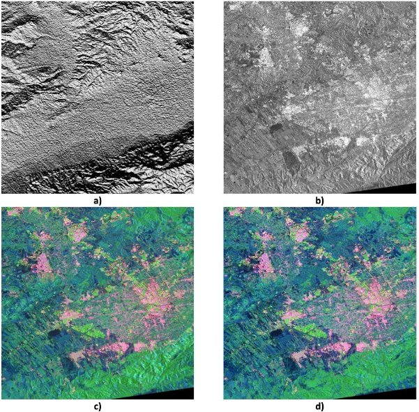

Figure 1: Example of polarimetric decomposition generated from ARD covariance format. a) Shaded DEM of the area; b) RADARSAT-2 HH intensity; c) Yamaguchi decomposition colour composite (Red: even bounce, Green: random, Blue: odd bounce); d) Same as c) with terrain flattening option. Generated from Radarsat-2 FQ18W acquired over Murcia, Spain on 18 June 2014 - ©MDA 2014

Figure 2 is a PRD compact polarimetric m-chi decomposition (Raney et al. 2012) simulated from two Canadian prairies Radarsat-2 fully polarimetric scenes acquired in May and June 2012. In May, before the growing season Figure 2a, m-chi shows mainly surface scattering from bare soil (blue channel) and vegetation interaction from forested areas (green channel), while in June Figure 2b growth of vegetation modifies the radar signal with interacting media function of the vegetation density and geometry which increase the amount of even bounce (red channel) and random scattering.

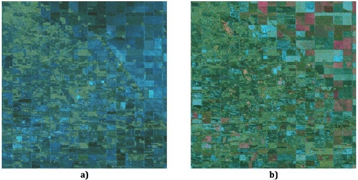

[^1]: For data crossing the North or South Pole, it is recommended to produce two distinct products and to use the appropriate “Pass direction” in each.